# spotify-dataset

```python
from pyspark import SparkContext, SparkConf
from pyspark.rdd import RDD
from pyspark.sql import SparkSession
import os
os.environ["PYSPARK_PYTHON"] = "./spark/bin/python3"
conf=SparkConf().setMaster("yarn").setAppName("spotify-dataset") \
        .set("spark.yarn.dist.archives","spark.tar.gz#spark") \
        .set("spark.executor.cores", "4") \
        .set("spark.executor.memory", "1g") \
        .set("spark.driver.memory", "3g")
sc = SparkContext(conf=conf)
spark = SparkSession.builder.appName('spotify-dataset').getOrCreate()
```

```
Setting default log level to "WARN".
To adjust logging level use sc.setLogLevel(newLevel). For SparkR, use setLogLevel(newLevel).
```

```python
sc
```

**SparkContext**

[Spark UI](http://edge:4050)

**Version**

`v3.5.0`

**Master**

`yarn`

**AppName**

`spotify-dataset`

# Read the data

```python
import datetime
import numpy as np
%matplotlib inline
import matplotlib.pyplot as plt
from pyspark.sql.functions import col, avg, rank, udf, desc, when
from pyspark.sql.types import IntegerType
from pyspark.sql.window import Window
from pyspark.ml.feature import StandardScaler, PCA, VectorAssembler
from pyspark.ml.linalg import DenseVector, Vectors
```

```python
file_path = "final_database.txt"
partition = 128
```

```python
df = spark.read.options(delimiter="\t", header=True).csv(os.path.join("data", file_path), header=True)
header = df.columns
df = df.filter(df['Uri']!='#').repartition(partition)
```

```python
df.select('Uri','Release_date').show()
```

```
[Stage 1:>                                                          (0 + 4) / 4]
```

```
+--------------------+------------+
|                 Uri|Release_date|
+--------------------+------------+
|https://open.spot...|   4-19-2017|
|https://open.spot...|   11-6-2015|
|https://open.spot...|    4-6-2018|
|https://open.spot...|        2019|
|https://open.spot...|    7-3-2020|
|https://open.spot...|   3-29-2019|
|https://open.spot...|    2-9-2018|
|https://open.spot...|   3-23-2018|
|https://open.spot...|   3-10-2017|
|https://open.spot...|   12-7-2018|
|https://open.spot...|    6-1-2018|
|https://open.spot...|   4-12-2018|
|https://open.spot...|   6-19-2020|
|https://open.spot...|   9-19-2018|
|https://open.spot...|   2-28-2020|
|https://open.spot...|   7-24-2020|
|https://open.spot...|   5-15-2020|
|https://open.spot...|  10-14-2011|
|https://open.spot...|    9-7-2017|
|https://open.spot...|   12-4-2015|
+--------------------+------------+
only showing top 20 rows
```

# Data preprocessing

To streamline the problem and enhance clarity, I have retained only the pertinent columns directly associated with the issue and renamed them for better understanding. Additionally, I have excluded entries with incorrect column orders to ensure data integrity.

```python
def extract_decade(date_str):
    if '-' in date_str:
        year = max(int(num) for num in date_str.split('-'))
    else:
        year = int(date_str)

    return (year // 10) * 10
```

```python
meaningful_cols = list(['Country0', 'Uri', 'Popularity', 'Title', 'Artist', \
                       'Album/Single', 'Genre_new', 'Artist_followers', \
                       'Release_date', 'Track_number', 'Tracks_in_album', \
                       'danceability', 'energy', 'speechiness', 'acoustics', 'instrumentalness', 'liveliness', \
                       'valence', 'time_signature'])
df = df.select(*meaningful_cols) \
        .withColumn("Decade", udf(extract_decade, IntegerType())(col("Release_date"))) \
        .withColumnRenamed('Country0', 'Country') \
        .withColumnRenamed('Genre_new', 'Genre')
```

# Find the number of unique songs

As the URI serves as the unique identifier for each song, my objective is to determine the count of distinct URIs within the dataset.

```python
unique_songs = df.select("Uri").distinct().count()
print(f'Number of unique songs: {unique_songs}')
```

```
[Stage 6:=====================================================> (124 + 4) / 128]
```

```
Number of unique songs: 62419
```

# Top 10 popular artists for all countries.

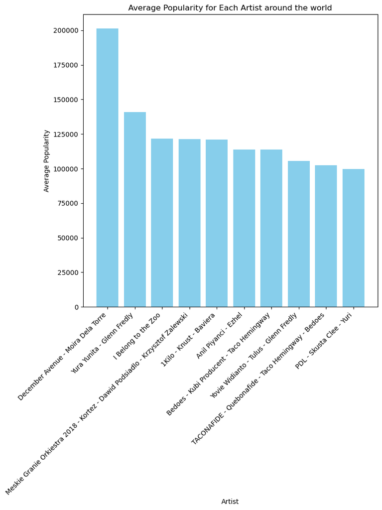

```python
artist_popularity = (
    df.groupBy("Artist")
    .agg(avg("popularity").alias("AveragePopularity"))
    .orderBy(desc("AveragePopularity"))
    .limit(10)
).collect()

# Plot the bar chart
plt.figure(figsize=(8,8))
plt.bar([row["Artist"] for row in artist_popularity], [row["AveragePopularity"] for row in artist_popularity], color='skyblue')
plt.xlabel("Artist")
plt.ylabel("Average Popularity")
plt.title("Average Popularity for Each Artist around the world")
plt.xticks(rotation=45, ha="right")

# Show the plot
plt.show()
```

# Show the most popular song (based on its popularity) for each decade

In the preprocessing phase, I converted the release dates to the corresponding release decades for the purpose of this task. Additionally, I computed the popularity for each song by taking their average popularity scores.

```python
# Aggregate and calculate the average popularity for each song
windowSpec = Window.partitionBy("Decade").orderBy(col("AveragePopularity").desc())
song_popularity = (
    df.groupBy("Decade", "Title", "Artist")
    .agg(avg("popularity").alias("AveragePopularity"))
).withColumn("rank", rank().over(windowSpec)).filter(col("rank") == 1).drop('rank')


# Select the top-ranked songs in each decade
song_popularity.show()
```

```
[Stage 25:>                                                         (0 + 4) / 4]
```

```
+------+--------------------+--------------------+------------------+
|Decade|               Title|              Artist| AveragePopularity|
+------+--------------------+--------------------+------------------+
|  1890|       rule britania|The Band Of H.M. ...|              20.8|
|  1900| roll out the barrel|The Beverley Sisters|            109.65|
|  1920|when you wish upo...|       Cliff Edwards|              22.4|
|  1930|         in the mood|        Glenn Miller|             163.0|
|  1940|     white christmas|Bing Crosby - Ken...| 4562.648214285714|
|  1950|let it snow! let ...|         Dean Martin|3393.7517241379305|
|  1960|its the most wond...|       Andy Williams|  6090.81935483871|
|  1970|bohemian rhapsody...|               Queen| 21810.67571428572|
|  1980|ahora te puedes m...|         Luis Miguel| 36417.34166666667|
|  1990|              dan...|         Sheila On 7|          173246.8|
|  2000|tell me where it ...|                MYMP|         122900.85|
|  2010|        kathang isip|             Ben&Ben|         204489.85|
|  2020|           bubbletea|Quebonafide - Dui...|           96478.9|
+------+--------------------+--------------------+------------------+
```

# Visualize the changing music over the decades

I calculated the average value of all songs in each decade for each feature.

## Take the average number for each music feature

```python
selected_columns = ['Decade', 'Uri', 'danceability', 'energy', 'speechiness', 'acoustics', 'instrumentalness', 'liveliness', 'valence']

trend_df = (
    df.select(*selected_columns)
    .dropDuplicates(['Uri'])
    .groupBy('Decade')
    .agg(avg('danceability').alias('avg_danceability'),
         avg('energy').alias('avg_energy'),
         avg('speechiness').alias('avg_speechiness'),
         avg('acoustics').alias('avg_acoustics'),
         avg('instrumentalness').alias('avg_instrumentalness'),
         avg('liveliness').alias('avg_liveliness'),
         avg('valence').alias('avg_valence')
         )
    .orderBy('Decade')
)

# Show the results
trend_df.show()
```

```
[Stage 35:>                                                         (0 + 4) / 4]
```

```
+------+------------------+-------------------+--------------------+-------------------+--------------------+-------------------+------------------+
|Decade|  avg_danceability|         avg_energy|     avg_speechiness|      avg_acoustics|avg_instrumentalness|     avg_liveliness|       avg_valence|
+------+------------------+-------------------+--------------------+-------------------+--------------------+-------------------+------------------+
|  1890|             0.281|              0.343|              0.0311|              0.829|               0.966|              0.254|             0.382|
|  1900|             0.549|              0.324|              0.0653|              0.755|             1.13E-6|              0.487|             0.589|
|  1920|             0.227|              0.446|               0.032|              0.851|             0.00912|              0.322|             0.119|
|  1930|              0.48|              0.293|0.061233333333333334| 0.9239999999999999| 0.16334023333333333|0.20576666666666665|             0.579|
|  1940|0.4063333333333333|0.21803333333333333| 0.04326666666666666| 0.8097222222222222| 0.08605004444444445|0.23831666666666665|0.4540222222222222|
|  1950|0.4756666666666666|0.36990277777777775|0.054311111111111116| 0.7464055555555557| 0.01211848111111111| 0.1675722222222222|0.5720833333333333|
|  1960| 0.516729064039409|0.47571379310344836| 0.05798226600985222| 0.5877163054187192|0.024660044876847288| 0.1901477832512315|0.6154596059113301|
|  1970|0.5470089020771515| 0.5433065875370919|  0.0524679525222552| 0.3702012462908012| 0.03892118160237389|0.17952997032640952| 0.607999703264095|
|  1980|0.5877803435114504| 0.6087480916030535| 0.05027977099236642|0.30094186240458015|0.027208680896946558|0.18091450381679383|0.6097929389312975|
|  1990|0.5795089766606824| 0.5987531418312387|0.054744344703770195|0.33197085446140023| 0.02707640666965888| 0.1787249551166966|0.5892034111310592|
|  2000|0.5812875734676743|  0.619314487825357| 0.06150340050377835|0.34361051802686826|0.024669176523929474|0.17875877413937857|0.5167626364399669|
|  2010|0.6654555078778263| 0.6457886020156689| 0.13031529574861422| 0.2649598512421882|0.015349369867749324| 0.1770942456649953|0.4964501496347146|
|  2020|0.6917640705958554| 0.6379262953367877|  0.1567200453367875| 0.2569331458071567| 0.01775087149773317|0.17414296470207302|0.5067329906088082|
+------+------------------+-------------------+--------------------+-------------------+--------------------+-------------------+------------------+
```

## Plot the trend

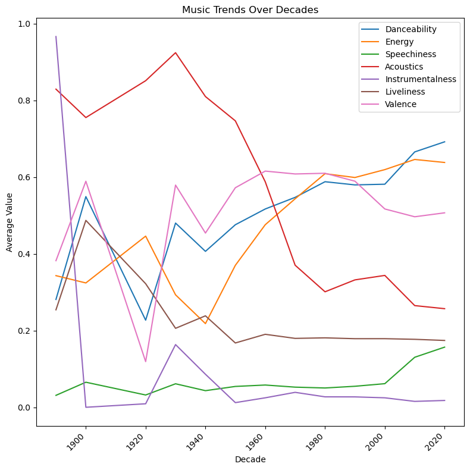

```python
trend_data = trend_df.collect()
plt.figure(figsize=(8,8))

plt.plot([row['Decade'] for row in trend_data], [row['avg_danceability'] for row in trend_data], label='Danceability')
plt.plot([row['Decade'] for row in trend_data], [row['avg_energy'] for row in trend_data], label='Energy')
plt.plot([row['Decade'] for row in trend_data], [row['avg_speechiness'] for row in trend_data], label='Speechiness')
plt.plot([row['Decade'] for row in trend_data], [row['avg_acoustics'] for row in trend_data], label='Acoustics')
plt.plot([row['Decade'] for row in trend_data], [row['avg_instrumentalness'] for row in trend_data], label='Instrumentalness')
plt.plot([row['Decade'] for row in trend_data], [row['avg_liveliness'] for row in trend_data], label='Liveliness')
plt.plot([row['Decade'] for row in trend_data], [row['avg_valence'] for row in trend_data], label='Valence')

plt.xlabel('Decade')
plt.ylabel('Average Value')
plt.title('Music Trends Over Decades')
plt.legend()
plt.xticks(rotation=45, ha='right')
plt.tight_layout()
plt.show()
```

# Build a recommender system

I drop all columns containing non-numeric data type and create 2 target column for the 'hip hop' and 'metal' attribute. Then I use PCA transformation.

```python
non_numeric_cols = set(['Country', 'Uri', 'Title', 'Artist', 'Album/Single', 'Album', 'Release_date', 'Genre'])
new_df = df.withColumn("hip hop", when(df["Genre"] == "hip hop", 1).otherwise(0)).withColumn("metal", when(df["Genre"] == "metal", 1).otherwise(0)).drop('Genre').dropDuplicates()
X = new_df.drop(*non_numeric_cols)
for column in X.columns:
    X = X.withColumn(column, col(column).cast('float'))
```

```python
assembler = VectorAssembler(inputCols=X.columns, outputCol="features", handleInvalid="skip")
X = assembler.transform(X)

sc = StandardScaler(inputCol="features", outputCol="scaled_features", withMean=True, withStd=True)
X = sc.fit(X).transform(X)

pca = PCA(k = 2, inputCol="scaled_features", outputCol="pca_features")
X = pca.fit(X).transform(X)
```

```
24/01/20 06:02:42 WARN SparkStringUtils: Truncated the string representation of a plan since it was too large. This behavior can be adjusted by setting 'spark.sql.debug.maxToStringFields'.
24/01/20 06:03:29 WARN InstanceBuilder: Failed to load implementation from:dev.ludovic.netlib.lapack.JNILAPACK
```

I converted the 'pca_features' column into a rdd and cast its values to an array for further operations

```python
def dist_centroids(point, centroids):
        return np.sum([(centroid[0]-point).dot(centroid[0]-point) for centroid in centroids])
def initialization(rdd, k):
    initial_points = [(rdd.takeSample(withReplacement=True,num=1)[0],np.array((1,1)),0)]
    for _ in range(k-1):
        point = rdd.map(lambda x: x[0]).map(lambda point: (point, dist_centroids(point,initial_points))).top(1, lambda x: x[1])[0]
        initial_points.append((np.array(point),np.array((1,1)),0))
    return initial_points
```

```python
pca_rdd = X.select('pca_features').rdd.map(lambda x: np.array(x[0])).repartition(16)
```

```
[Stage 91:====================================================> (124 + 4) / 128]
```

```python
def maha_distance(m,n):
    vec = np.divide(m-n[0],n[1])
    return (vec.dot(vec)) ** 0.5

def nearest_centroid_idx(point, centroids):
    min = 1000
    id =-1
    for i in range(len(centroids)):
        d=maha_distance(point, centroids[i])
        if (d<min) and (d<3*(np.sqrt(2))):
            min = d
            id = i
    return id

def assign_point_to_centroid(point, centroids):
    centroid_idx = nearest_centroid_idx(point, centroids)
    return (centroid_idx, (point, point*point,1))

def update_cluster(x, y):
    sum = x[0]+y[0]
    sumsq = x[1]+y[1]
    n = x[2] + y[2]
    return (sum, sumsq, n)

def new_centroid(updated_cluster):
    idx, points = updated_cluster
    sum, sumsq, n = points
    variance = (sumsq / n) - ((sum / n) ** 2)
    std_dev = np.sqrt(variance)
    centroid = sum / n
    return (idx, (centroid, std_dev, n))

def new_centroids(assign_rdd):
    return assign_rdd.reduceByKey(update_cluster).map(new_centroid).filter(lambda x: x[0]!=-1) \
                    .sortBy(lambda x: x[0]) \
                    .map(lambda x: x[1]) \
                    .collect()
```

```python
def bfr(rdd, k):
    centroids = initialization(rdd, k)
    cluster_rdd = rdd.map(lambda point: (point, -1))
    max_iter=10
    for _ in range(max_iter):
        if len(centroids)<k:
            generated_centroids=initialization(cluster_rdd.filter(lambda x: x[1]==-1).map(lambda x: x[0]), k-len(centroids))
            for generated_centroid in generated_centroids:
                centroids.append(generated_centroid)
        assign_rdd = cluster_rdd.map(lambda point: assign_point_to_centroid(point[0], centroids))
        cluster_rdd = assign_rdd.map(lambda x: (x[1][0], x[0]))
        centroids = new_centroids(assign_rdd)
    return cluster_rdd, centroids
```

```python
cluster_rdd, centroids= bfr(pca_rdd,8)
```

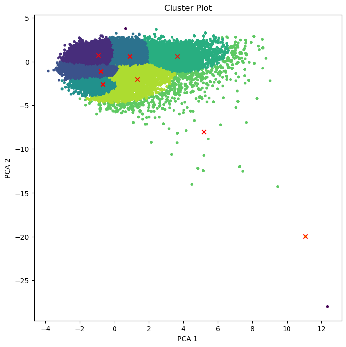

```python
points = cluster_rdd.collect()
x_values = [point[0][0] for point in points]
y_values = [point[0][1] for point in points]
cluster_values = [point[1] for point in points]


plt.figure(figsize=(8,8))
# Plot points with cluster-specific colors
plt.scatter(x_values, y_values, c=cluster_values, marker=".", label='Points')
plt.scatter([x[0][0] for x in centroids],[x[0][1] for x in centroids], c='red', marker="x", label='Centroids')
plt.title('Cluster Plot')
plt.xlabel('PCA 1')
plt.ylabel('PCA 2')
plt.show()
```